# STT 420 Exam 1

Thomas Billman

October 18, 2018

We begin this reponse by reading in our data:

```r
dat <- read.csv(file = url("https://raw.githubusercontent.com/tbillman/STT-420/master/Exam1data.csv"))
dat
```

```
##    ID duration age category public coastal
## 1   1        7  30        1      1       1
## 2   2       12  73        2      1       1
## 3   3        3  40        0      1       0
## 4   4       15  47        2      1       1
## 5   5        9  25        2      1       1
## 6   6       92  82        5      0       1
## 7   7        4  60        0      0       0
## 8   8       32  56        3      1       1
## 9   9       17  43        1      1       1
## 10 10        6  50        4      0       0
## 11 11        2  59        0      1       1
## 12 12        8   4        3      1       1
## 13 13        6  22        2      0       1
## 14 14       11  33        3      0       0
```

[output cut: 36 more lines]

```r
attach(dat)
```

Also our provided codebook gives us the following information about the variables:

ID- Subject identification

duration - Duration of closure in days

age - age of university in years

category - storm category, 6 levels from 0 (tropical storm) to 5 (category 5 hurricane)

public - Whether or not the university is public, 1: Yes, 0: No

coastal - Whether or not the university is considered coastal, 1: Yes, 0: No

#### 1) Create tables and summary graphs for the data. Describe what you find from these in a sentence or two.

We begin by creating tables and graphs:

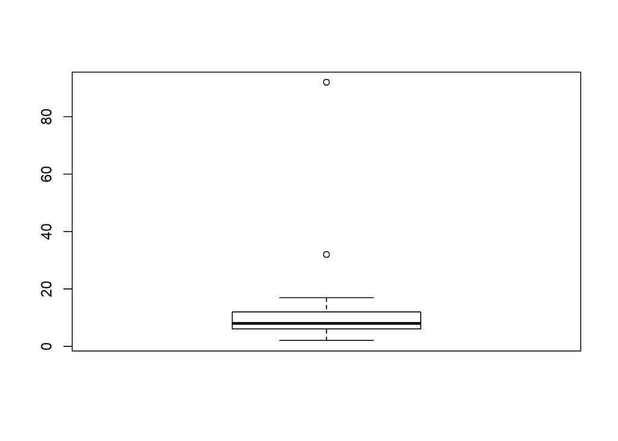

```r
boxplot(duration)
```

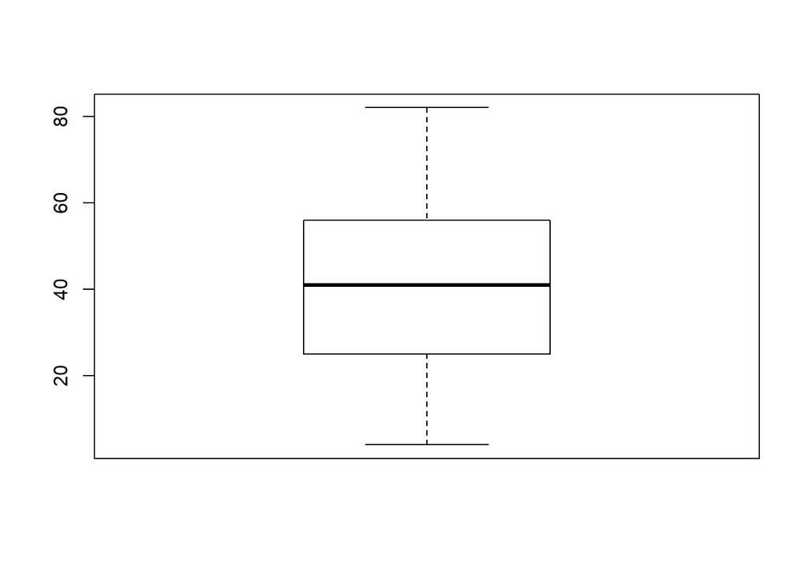

```r
boxplot(age)
```

```r
table(category)
```

```
## category
## 0 1 2 3 4 5
## 4 6 7 5 2 1
```

```r
table(public)
```

```
## public
##  0  1
##  7 18
```

```r
table(coastal)
```

```
## coastal
##  0  1
##  6 19
```

```r
summary(dat)
```

```
##        ID           duration          age           category
##  Min.   : 1.00   Min.   : 2.00   Min.   : 4.00   Min.   :0.00
##  1st Qu.:13.25   1st Qu.: 6.00   1st Qu.:25.00   1st Qu.:1.00
##  Median :25.50   Median : 8.00   Median :41.00   Median :2.00
##  Mean   :25.50   Mean   :12.68   Mean   :41.24   Mean   :1.92
##  3rd Qu.:37.75   3rd Qu.:12.00   3rd Qu.:56.00   3rd Qu.:3.00
##  Max.   :50.00   Max.   :92.00   Max.   :82.00   Max.   :5.00
##                  NA's   :25      NA's   :25      NA's   :25
##      public        coastal
##  Min.   :0.00   Min.   :0.00
##  1st Qu.:0.00   1st Qu.:1.00
##  Median :1.00   Median :1.00
##  Mean   :0.72   Mean   :0.76
##  3rd Qu.:1.00   3rd Qu.:1.00
##  Max.   :1.00   Max.   :1.00
##  NA's   :25     NA's   :25
```

The boxplot and summary of the duration variable shows that the inner 50% of the data lies between 6 and 12 days. However this data has two outlying values of 32 days and 92 days.

The age variable seems fairly normally distributed without any outlying points.

The category variable shows that the most likely storms are category 1 or 2, with moderate probabilities for categories 0 or 3. There were very few cases of category 4 or 5 hurricanes.

18 of our 25 universities were public.

19 of our 25 universities were coastal.

#### 2) It is of interest to know if the duration of closure is affected by whether or not a univesity is public or private. Answer this question descriptively using combinations of numeric, graphic, and testing methods. Include a sentence or two describing your results. (Hint: Can we assume normality?)

To address this concern we constructing a simple linear model to view initial results.

```r
slm <- lm(duration ~ public)
summary(slm)
```

```
##
## Call:
## lm(formula = duration ~ public)
##
## Residuals:
##     Min      1Q  Median      3Q     Max
## -14.857  -8.278  -3.278   1.722  73.143
##
## Coefficients:
##             Estimate Std. Error t value Pr(>|t|)
## (Intercept)   18.857      6.654   2.834  0.00941 **
## public        -8.579      7.842  -1.094  0.28526
## ---
## Signif. codes:  0 '***' 0.001 '**' 0.01 '*' 0.05 '.' 0.1 ' ' 1
##
## Residual standard error: 17.6 on 23 degrees of freedom
##   (25 observations deleted due to missingness)
## Multiple R-squared:  0.04947,    Adjusted R-squared:  0.008139
## F-statistic: 1.197 on 1 and 23 DF,  p-value: 0.2853
```

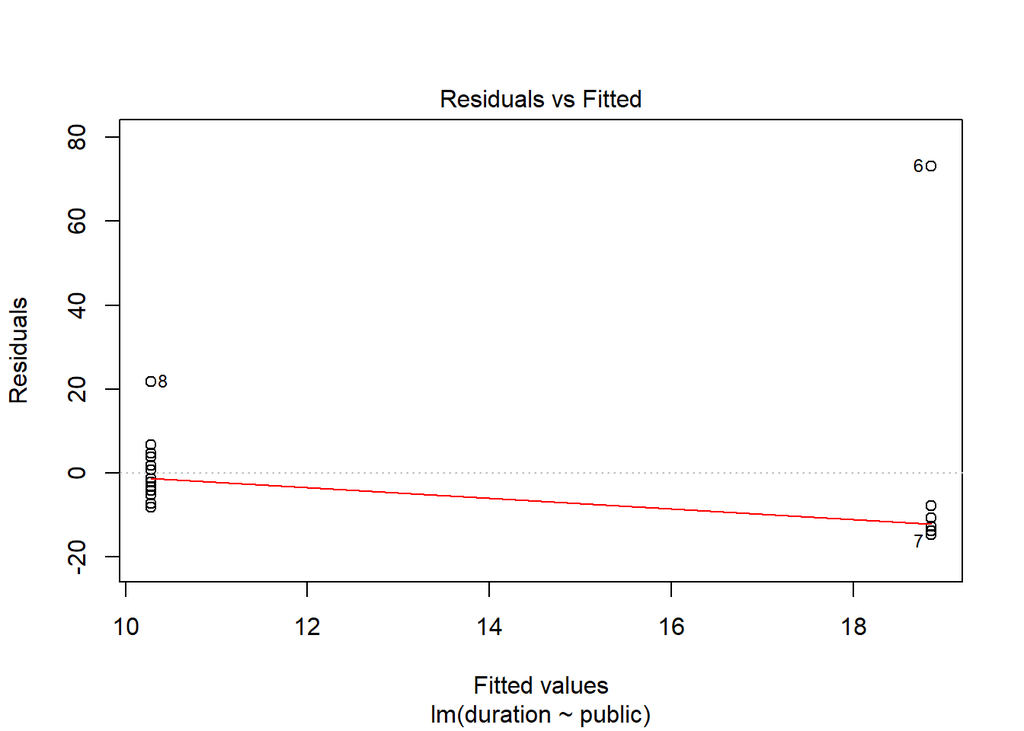

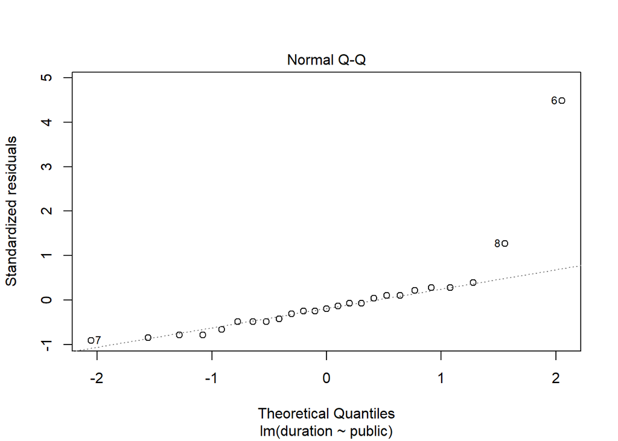

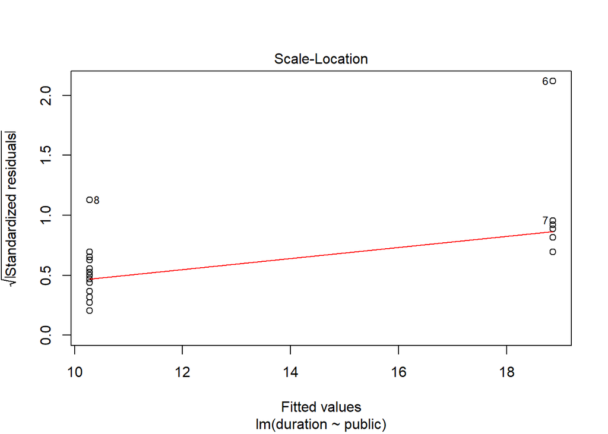

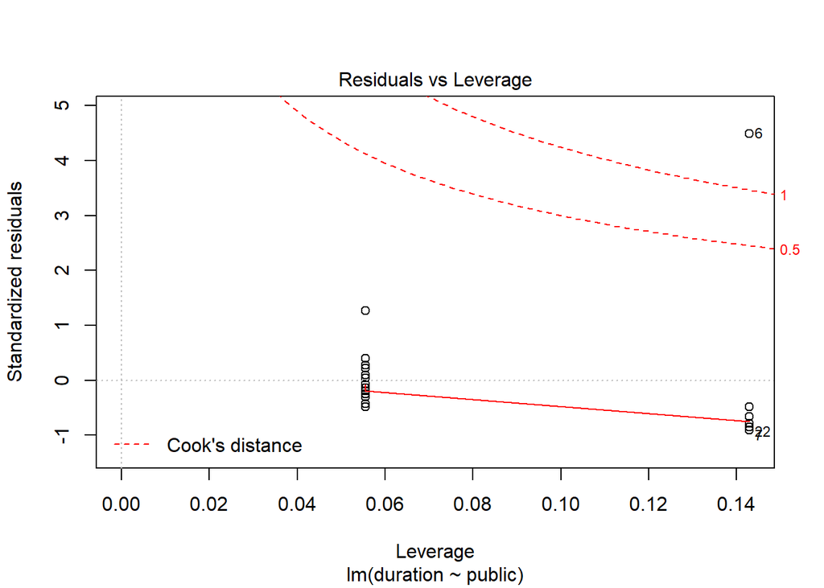

```r
plot(slm)
```

This summary shows that there is not a significant relationship, however we have a few points that seem out of the ordinary. To address this we inspect them individually.

```r
dat[6:8,]
```

```
##   ID duration age category public coastal
## 6  6       92  82        5      0       1
## 7  7        4  60        0      0       0
## 8  8       32  56        3      1       1
```

```r
newdat <- dat[c(-6,-26:-50),]
detach(dat)
attach(newdat)
newslm <- lm(duration ~ public)
summary(newslm)
```

```
##
## Call:
## lm(formula = duration ~ public)
##
## Residuals:
##     Min      1Q  Median      3Q     Max
## -8.2778 -3.5278 -0.9722  2.2222 21.7222
##
## Coefficients:
##             Estimate Std. Error t value Pr(>|t|)
## (Intercept)    6.667      2.592   2.572   0.0174 *
## public         3.611      2.993   1.206   0.2405
## ---
## Signif. codes:  0 '***' 0.001 '**' 0.01 '*' 0.05 '.' 0.1 ' ' 1
##
## Residual standard error: 6.349 on 22 degrees of freedom
## Multiple R-squared:  0.06205,    Adjusted R-squared:  0.01942
## F-statistic: 1.456 on 1 and 22 DF,  p-value: 0.2405
```

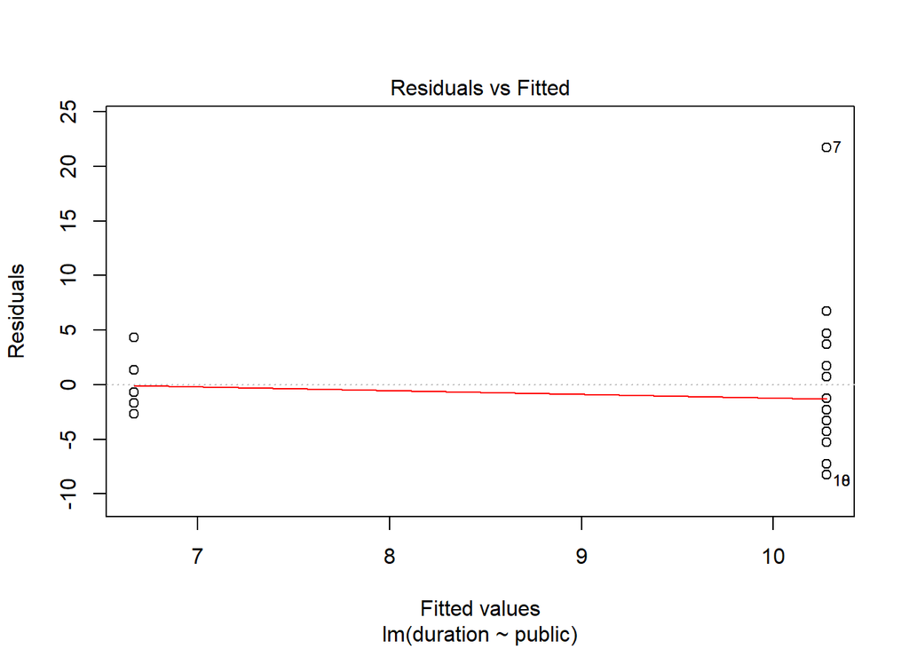

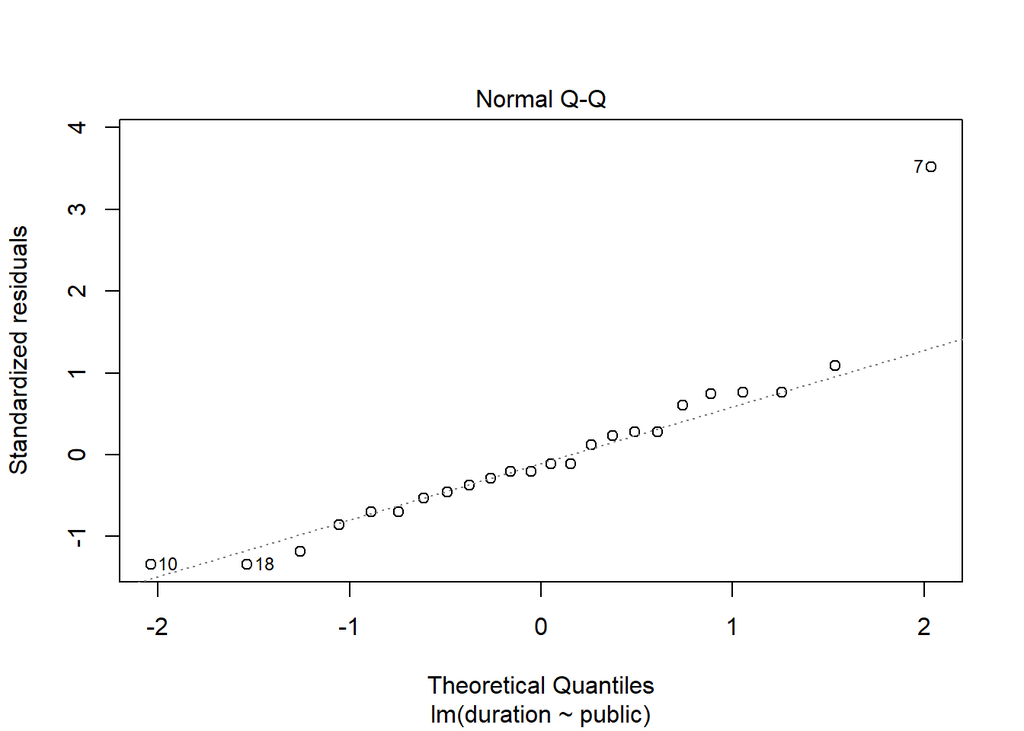

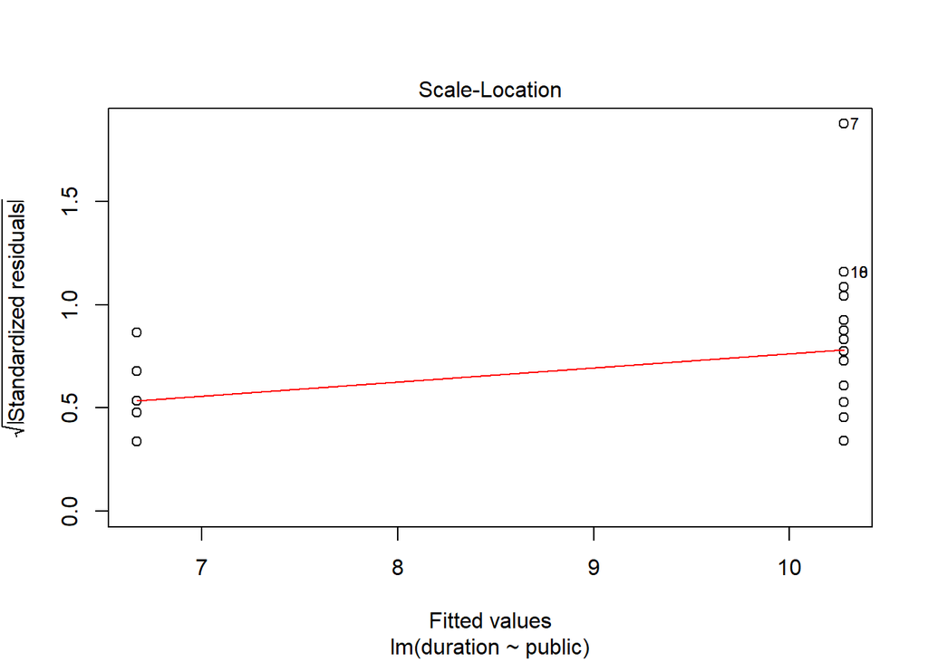

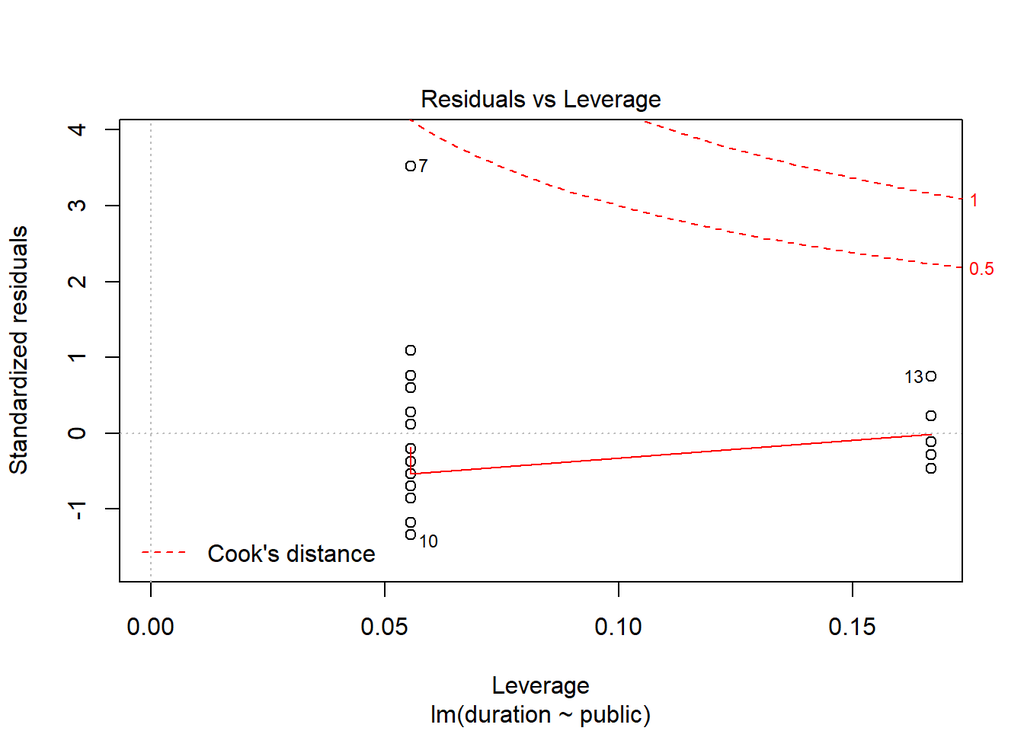

```r
plot(newslm)
```

In this case observation 7 still stands out, however the rest of our plots look fairly supportive of the assumptions behind linear regression. Given that the summary of the linear model still shows a p-value greater than .05 for $H_o:\hat\beta_{public}=0$ and $H_a:\hat\beta_{public}\neq0$ we fail to reject $H_o$ and can not conclude that there exists a relationship between just whether an institution is public or private and the recovery duration.

#### 3) What smaple size would be needed to be able to detect a difference of this size with a power of 0.8 and a significance level of 0.05? (Hint: Difference in the mean duration of closure for public and private universities).

To estimate this sample size we use the formula for comparing independent means:

$N = \frac{2(Z_{1-\alpha/2} + Z_{1-\beta})^2}{\Delta^2}$ where $\Delta = \frac{\mu_1-\mu_0}{\sigma}$

we estimate $\mu_1$ and $\mu_0$ as the mean durations for private and public schools respectively. We estimate $\sigma$ as the total standard deviation of the duration. And let $\alpha = .05$ and $1-\beta = .8$

```r
m1 <- mean(duration[public==0]) ;m1
```

```
## [1] 6.666667
```

```r
m0 <- mean(duration[public==1]) ;m0
```

```
## [1] 10.27778
```

```r
sig <- sd(duration)   ;sig
```

```
## [1] 6.41203
```

```r
del <- (m1-m0)/sig    ;del
```

```
## [1] -0.5631775
```

```r
za <- qnorm(p = .975) ;za
```

```
## [1] 1.959964
```

```r
zb <- qnorm(p = .8)   ;zb
```

```
## [1] 0.8416212
```

```r
N <- 2*((za + zb)^2)/(del^2)
N
```

```
## [1] 49.49338
```

This implies we would need a sample size of 50 with equal sized samples of 25 private and 25 public universities.

#### 4) Calculate sensitivity, specificity, AUC, and RR and test for an association between category vs. public and coastal vs. public. Interpret all results, and compare the relationships in words. (Hints: first create two by two tables, and think about what test is appropriate for this size data).

#### Category vs. Public

We begin with a table of category vs. public.

```r
table(category,public)
```

```
##         public
## category 0 1
##        0 1 3
##        1 2 4
##        2 1 6
##        3 1 4
##        4 1 1
```

Additionally, we need to install/load the pROC package for R to easily construct an ROC curve

```r
#install.packages("pROC")
library(pROC)
```

```r
curve <- roc(public,category)
curve
```

```
##
## Call:
## roc.default(response = public, predictor = category)
##
## Data: category in 6 controls (public 0) < 18 cases (public 1).
## Area under the curve: 0.5
```

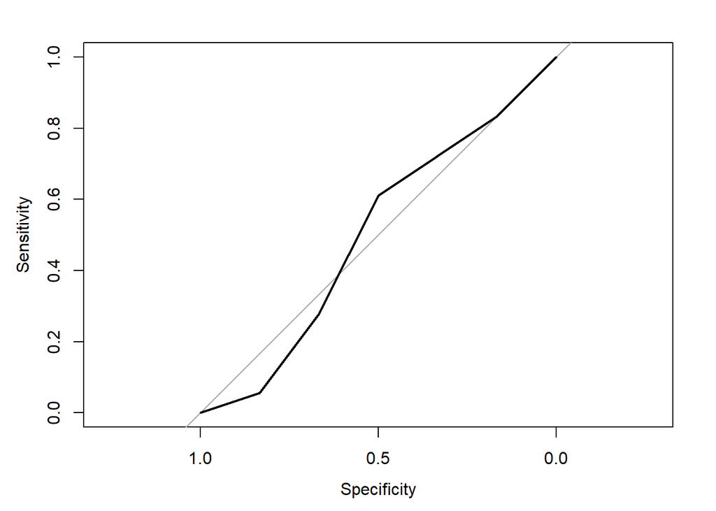

```r
plot(curve)
```

This shows that the sensitivity and specificity are not well related between category and public. Additionally, our AUC was only .5 which is very insignificant.

#### Coastal vs. Public

We begin with a table of coastal vs. public.

```r
table(coastal,public)
```

```
##        public
## coastal  0  1
##       0  4  2
##       1  2 16
```

Then we construct our ROC curve

```r
curve <- roc(public,coastal)
curve
```

```
##
## Call:
## roc.default(response = public, predictor = coastal)
##
## Data: coastal in 6 controls (public 0) < 18 cases (public 1).
## Area under the curve: 0.7778
```

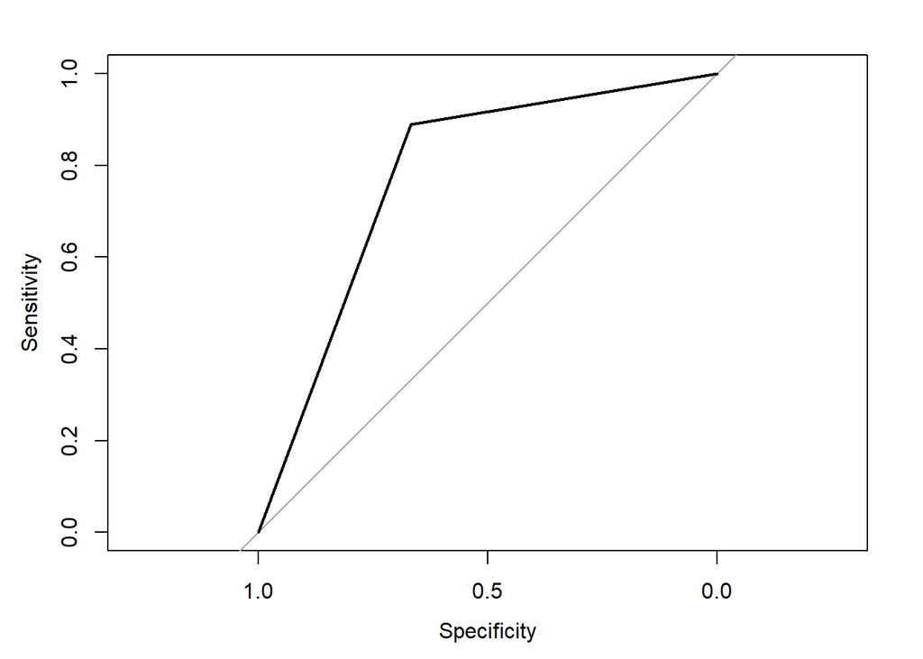

```r
plot(curve)
```

```r
chisq.test(table(coastal,public))
```

```
##
##  Pearson's Chi-squared test with Yates' continuity correction
##
## data:  table(coastal, public)
## X-squared = 4.7407, df = 1, p-value = 0.02946
```

This suggests a more significant relationship. If we use the cutoff between 0 and 1 our sensitivity is 16/18 and our specificity is 4/6. Our AUC here is .7778 which is better than .5. To do an additional test, we conduct a chi squared goodness of fit test with a continuity correction to get a p value of ~.03 indicating some statistical association between whether a school is coastal and if it is public.

#### 5) If the duration of closure was approximately normally distributed with a mean of 11.5 days and a standard deviation of 3 days, what is the probability that, following a hurricane, a university is closed for: (don’t simply state the probability, write a senence about it.)

#### a) between 8.5 and 14.5 days?

To calculate this probability we begin by translating 8.5 days and 14.5 days to z scores using the following formula:

$Z = \frac{x-\mu}{\sigma}$

where $\mu = 11$ and $\sigma = 3$.

This leads us to the following Z values:

$Z_{8.5} = -.8\bar{3}$

$Z_{14.5} = 1.1\bar{6}$

Then we compute the probability a random observation on the standard normal table would be less than $Z_{14.5}$ but greater than $Z_{8.5}$. This can be computed as $\Phi(Z_{14.5}) - \Phi(Z_{8.5})$

```r
z1 <- (8.5-11)/3
z0 <- (14.5 - 11)/3
pnorm(z0) - pnorm(z1)
```

```
## [1] 0.6759991
```

We follow the above process for the next two parts of the question:

#### b) Over 10 days.

This will be calculated as $1 - \Phi(Z_{10})$

```r
z <- (10-11)/3
1 - pnorm(z)
```

```
## [1] 0.6305587
```

This means there is a 63.1% chance that a random closure would be greater than 10 days.

#### c) Under 12 days.

This will be calculated as $\Phi(Z_{12})$

```r
z <- (12-11)/3
pnorm(z)
```

```
## [1] 0.6305587
```

This means there is a 63.1% chance that a random closure would be under 12 days. It is worth noting that this is the same probability as the previous subquestion due to the symmetry of the normal distribution.

#### 6) In question 4 we dichotomized the category variable to calculate the requested statistics. How can we test the association between the full category of hurrican variable (without dichotomization) and type of university (public vs. private)? Perofrm this test and interpret the results. (Hint: Are these test results reasonable?)

In this case we would use the Wilcoxon rank test to compare an oridinal covariate to a binary response.

```r
table(category,public)
```

```
##         public
## category 0 1
##        0 1 3
##        1 2 4
##        2 1 6
##        3 1 4
##        4 1 1
```

```r
wilcox.test(table(category,public))
```

```
##
##  Wilcoxon signed rank test with continuity correction
##
## data:  table(category, public)
## V = 55, p-value = 0.005264
## alternative hypothesis: true location is not equal to 0
```

This shows us that there exists a significant relationship between category and public university given that our p-value was ~ .005. However, this may also be a result of more public universities being coastal as shown in the second part of problem 4.